# pacu: Precision Agriculture Computational Utilities - Weather data

Caio dos Santos & Fernando Miguez

2025-11-18

# Specific vignettes

1. Satellite data
2. Weather data
3. Yield monitor data
4. Frequently asked questions

# Weather data

## Obtaining weather data

There are several packages and utilities that allow for downloading weather data. Here we use the **apsimx** package. This package has simple wrappers that ‘get’ weather from different sources:

- Iowa Environmental Mesonet
- NASA-POWER (via nasapower package)
- DayMet (via daymetr package)
- CHIRPS (via chirps package)

For more details about getting and working with weather data see the **apsimx** package.

## Using apsimx and pacu packages

### Gathering and summarizing weather data

An alternative way of investigating the growing conditions experienced by crops in a given year would be to summarize the weather data and place it in a historical context. Let us download some weather data first.

```r
weather.met <- pa_get_weather_sf(area.of.interest, '1990-01-01', '2020-12-31')
```

We can make simple plots for precipitation or temperature. A filter is used to subset years 2017 to 2020 for easier interpretation.

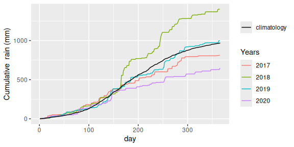

```r
## Precipitation (or rain)
plot(weather.met, met.var = "rain", cumulative = TRUE,
     climatology = TRUE, years = 2017:2020)
```

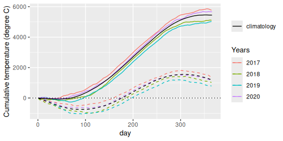

```r
## Temperature
plot(weather.met, cumulative = TRUE,
     climatology = TRUE, years = 2017:2020)
```

There is a summary function for simple display of statistics

```r
## Selecting just a few columns (1, 6, 7, 10) for simplicity
summary(weather.met, years = 2017:2020)[, c(1, 6, 7, 10)]
```

```
##   year avg_maxt avg_mint rain_sum
## 1 2017    15.79     3.72   814.04
## 2 2018    14.01     2.81  1401.30
## 3 2019    13.75     2.17   998.94
## 4 2020    15.47     3.11   644.34
```

The apsimx package does not produce complex graphs for weather data. This was included here to allow more detailed interpretation of crop performance data for a given location. In the pacu package we include functions which can summarize data in a historical context.

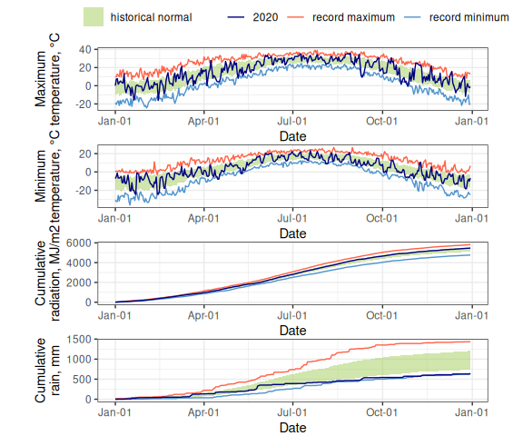

```r
pa_plot(weather.met,
        plot.type = 'climate_normals',
        unit.system = 'int')
```

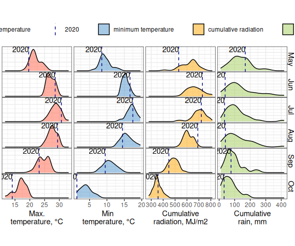

```r
pa_plot(weather.met,
        plot.type = 'monthly_distributions',
        unit.system = 'int', months = 5:10)
```